# berkcan_erguncu_hwmidterm

Berkcan Erguncu

12/7/2020

```r
data =read.csv("/cloud/project/data_science/midterm/online_shoppers_intention.csv")
summary(data)
```

```
##  Administrative   Administrative_Duration Informational
##  Min.   : 0.000   Min.   :   0.00         Min.   : 0.0000
##  1st Qu.: 0.000   1st Qu.:   0.00         1st Qu.: 0.0000
##  Median : 1.000   Median :   7.50         Median : 0.0000
##  Mean   : 2.315   Mean   :  80.82         Mean   : 0.5036
##  3rd Qu.: 4.000   3rd Qu.:  93.26         3rd Qu.: 0.0000
##  Max.   :27.000   Max.   :3398.75         Max.   :24.0000
##
##  Informational_Duration ProductRelated   ProductRelated_Duration
##  Min.   :   0.00        Min.   :  0.00   Min.   :    0.0
##  1st Qu.:   0.00        1st Qu.:  7.00   1st Qu.:  184.1
##  Median :   0.00        Median : 18.00   Median :  598.9
##  Mean   :  34.47        Mean   : 31.73   Mean   : 1194.8
##  3rd Qu.:   0.00        3rd Qu.: 38.00   3rd Qu.: 1464.2
##  Max.   :2549.38        Max.   :705.00   Max.   :63973.5
##
##   BounceRates         ExitRates         PageValues        SpecialDay
##  Min.   :0.000000   Min.   :0.00000   Min.   :  0.000   Min.   :0.00000
##  1st Qu.:0.000000   1st Qu.:0.01429   1st Qu.:  0.000   1st Qu.:0.00000
##  Median :0.003112   Median :0.02516   Median :  0.000   Median :0.00000
##  Mean   :0.022191   Mean   :0.04307   Mean   :  5.889   Mean   :0.06143
##  3rd Qu.:0.016813   3rd Qu.:0.05000   3rd Qu.:  0.000   3rd Qu.:0.00000
##  Max.   :0.200000   Max.   :0.20000   Max.   :361.764   Max.   :1.00000
##
##      Month      OperatingSystems    Browser           Region
##  May    :3364   Min.   :1.000    Min.   : 1.000   Min.   :1.000
##  Nov    :2998   1st Qu.:2.000    1st Qu.: 2.000   1st Qu.:1.000
##  Mar    :1907   Median :2.000    Median : 2.000   Median :3.000
##  Dec    :1727   Mean   :2.124    Mean   : 2.357   Mean   :3.147
##  Oct    : 549   3rd Qu.:3.000    3rd Qu.: 2.000   3rd Qu.:4.000
##  Sep    : 448   Max.   :8.000    Max.   :13.000   Max.   :9.000
##  (Other):1337
##   TrafficType               VisitorType     Weekend         Revenue
##  Min.   : 1.00   New_Visitor      : 1694   Mode :logical   Mode :logical
##  1st Qu.: 2.00   Other            :   85   FALSE:9462      FALSE:10422
##  Median : 2.00   Returning_Visitor:10551   TRUE :2868      TRUE :1908
##  Mean   : 4.07
##  3rd Qu.: 4.00
##  Max.   :20.00
##
```

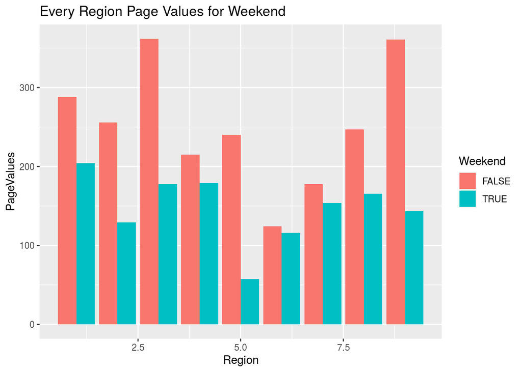

```r
ggplot(data, aes(x=Region, y=PageValues, fill=Weekend)) +
  geom_bar(stat="identity", position=position_dodge())+
  labs(title = "Every Region Page Values for Weekend")
```

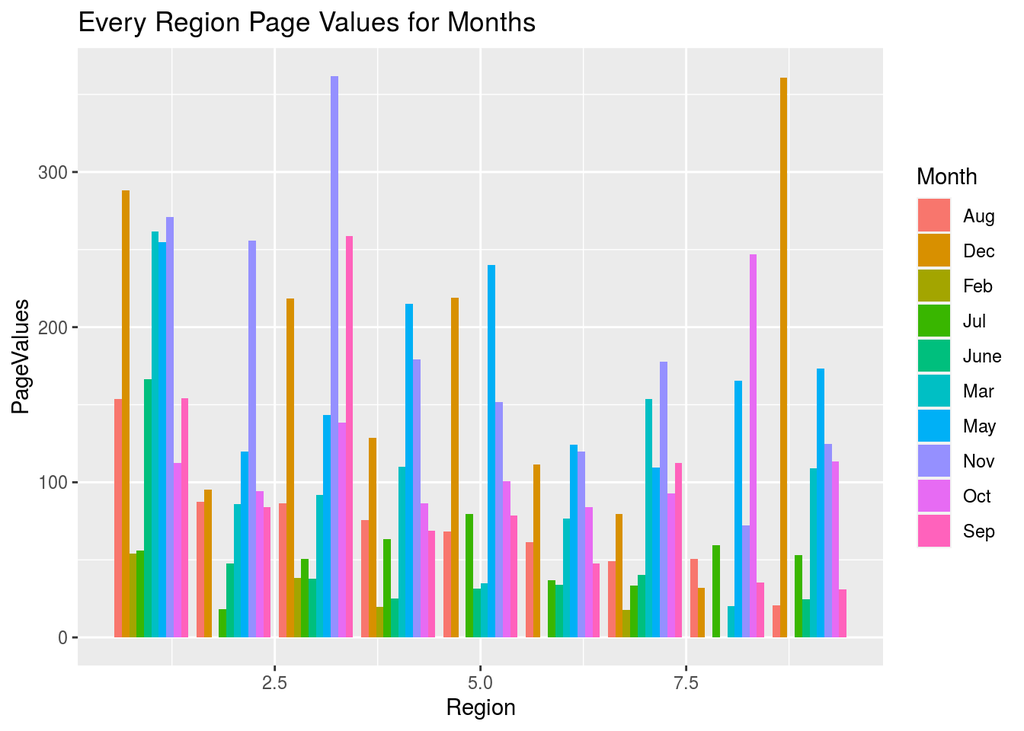

```r
ggplot(data, aes(x=Region, y=PageValues, fill=Month)) +
  geom_bar(stat="identity", position=position_dodge())+
  labs(title = "Every Region Page Values for Months")
```

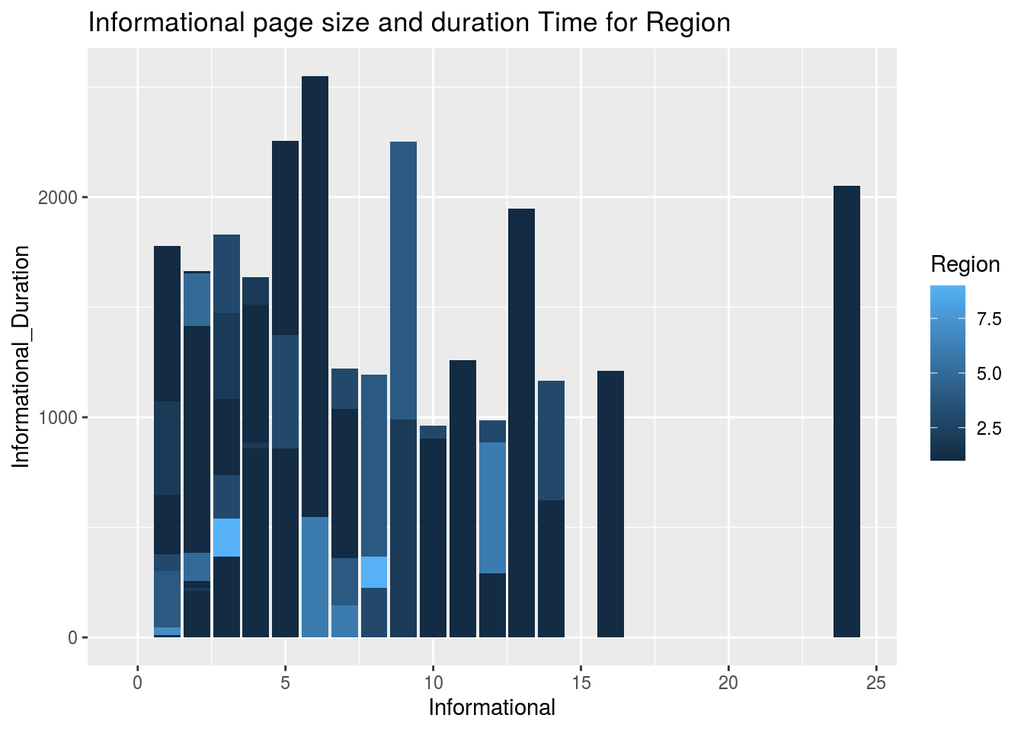

```r
ggplot(data, aes(x=Informational, y=Informational_Duration, fill=Region)) +
  geom_bar(stat="identity", position=position_dodge())+
  labs(title = "Informational page size and duration Time for Region")
```

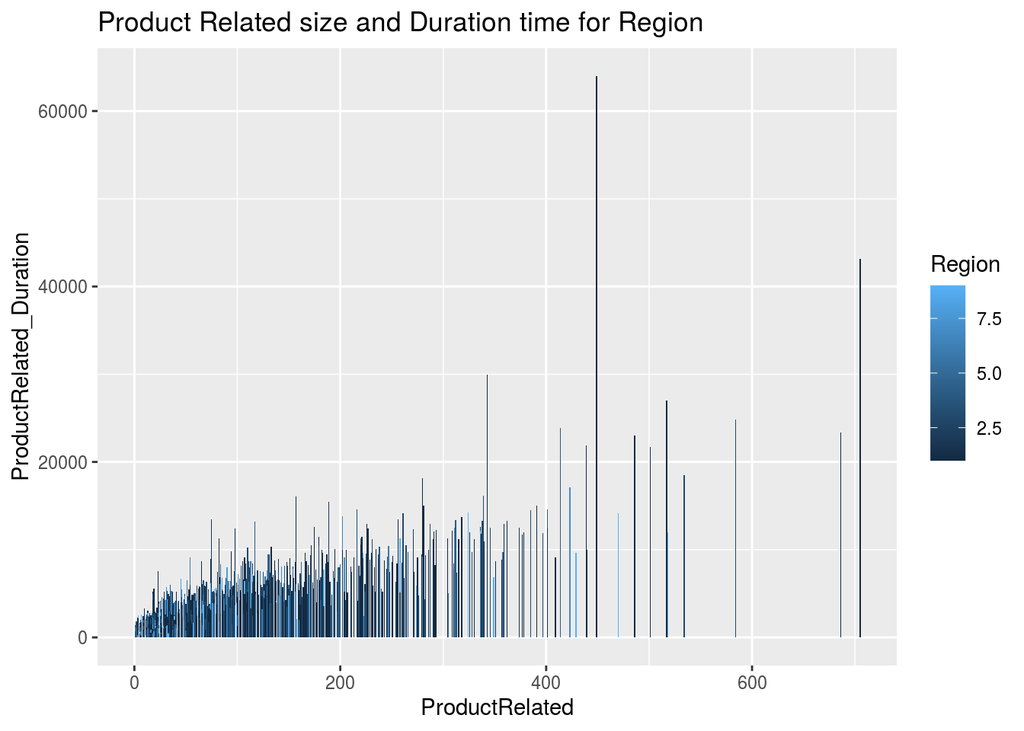

```r
ggplot(data, aes(x=ProductRelated,y=ProductRelated_Duration, fill=Region)) +
  geom_bar(stat="identity", position=position_dodge())+
  labs(title = "Product Related size and Duration time for Region")
```

## My focus area

```r
Region_shop = data %>% select(3,4,5,6,7,8,9,11,14,17,18)
Region_count = Region_shop %>% count(Region)
Average_Region_shop = aggregate(Region_shop[, 1:7], list(Region_shop$Region), mean)
Average_Region_shop$Customer = Region_count$n

names(Average_Region_shop)[names(Average_Region_shop) == "Group.1"] <- "Region"
```

I’m focusing to customer shopping activities in each region. These activities are based on the number of sites they use, the number of products they have viewed and the time they have been on these pages. I then recorded the averages of the activities in these regions. That’s why I removed the other columns from the dataset.

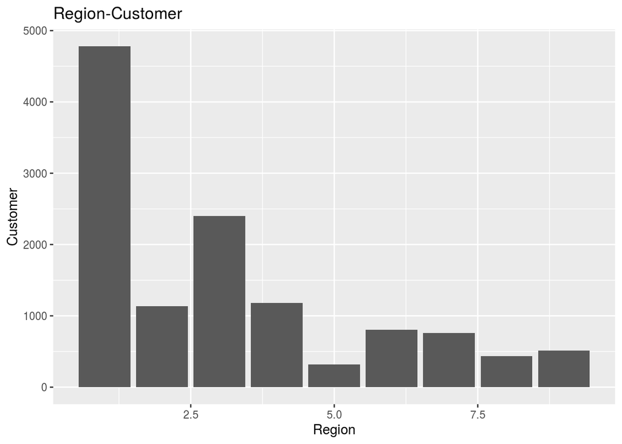

```r
ggplot(Average_Region_shop, aes(x=Region,y=Customer)) +
  geom_bar(stat="identity", position=position_dodge())+
  labs(title = "Region-Customer ")
```

Each region has different customer numbers. it is seen that the largest region is 1 and the smallest region is 5.

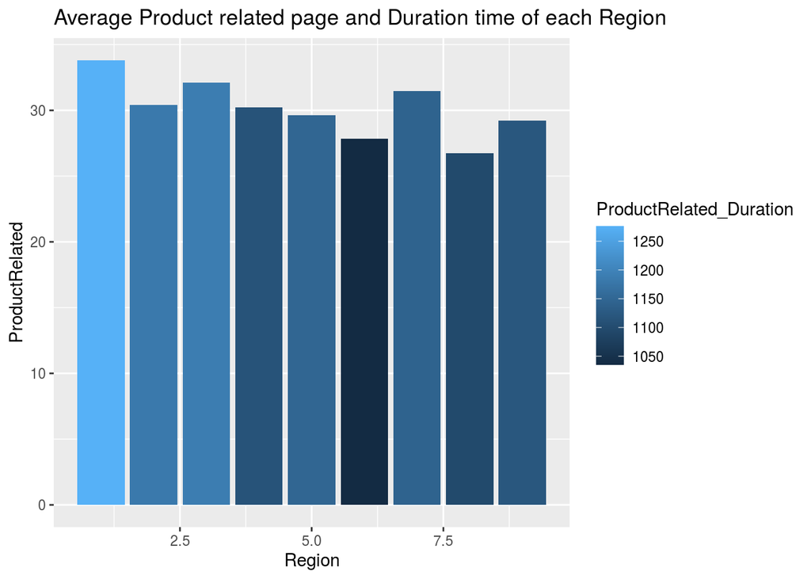

```r
ggplot(Average_Region_shop, aes(x=Region,y=ProductRelated, fill=ProductRelated_Duration)) +
  geom_bar(stat="identity", position=position_dodge())+
  labs(title = "Average Product related page and Duration time of each Region")
```

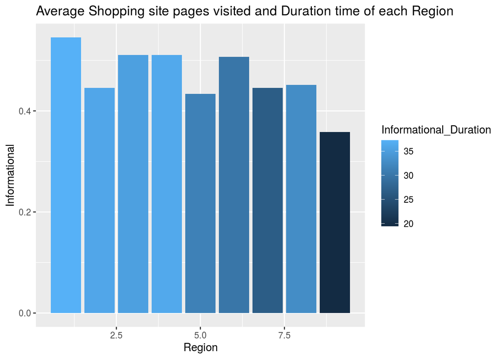

```r
ggplot(Average_Region_shop, aes(x=Region,y=Informational, fill=Informational_Duration)) +
  geom_bar(stat="identity", position=position_dodge())+
  labs(title = "Average Shopping site pages visited and Duration time of each Region")
```